# Mice Pheno - Data handling and visualisation

Alisson G. Chiquitto chiquitto@gmail.com

2022-10-12

By the end of this first interactive tutorial you will be able to:

- explore and manipulate data frames in R
- use the R package ggplot2 to visualise data

## Resources

This lecture is based on the EMBL Bio-IT course [“Introduction to R”](https://grp-bio-it-workshops.embl-community.io/introduction-to-R/index.html), which in turn is based on [Data Carpentry](https://datacarpentry.org/) materials. The mouse data are from Winzell and Ahrén (2004) https://diabetes.diabetesjournals.org/content/53/suppl_3/S215.

## Setup

This first tutorial is an introduction to data handling, exploration and plotting in R. Before we can think about useful statistical analysis of our data, we first have to get an overview how they look like. And for many scientific questions, the answer will already be apparent when looking at the right plots.

We start by loading the required packages. `ggplot2` is included in the tidyverse package.

```r
library(tidyverse)
library(Hmisc)
```

## Load mice_pheno dataset

We load the `mice_pheno` data into R:

```r
# mice_pheno <- read.csv2(file= url("https://raw.githubusercontent.com/genomicsclass/dagdata/master/inst/extdata/mice_pheno.csv"), sep=",")
mice_pheno <- read.csv2(file="dataset/mice_pheno.csv", sep=",")
mice_pheno$Bodyweight <- as.numeric(mice_pheno$Bodyweight)
```

We can see this when inspecting the structure of a data frame with the function `str()`:

```r
str(mice_pheno)
```

```
'data.frame':   846 obs. of  3 variables:
 $ Sex       : chr  "F" "F" "F" "F" ...
 $ Diet      : chr  "hf" "hf" "hf" "hf" ...
 $ Bodyweight: num  31.9 32.5 22.8 19.9 32.2 ...
```

## Explore the data frame

Size:

- `dim(mice_pheno)` - returns a vector with the number of rows in the first element, and the number of columns as the second element (the dimensions of the object)

Content:

- `head(mice_pheno)` - shows the first 6 rows

Names:

- `names(mice_pheno)` - returns the column names (synonym of colnames() for data.frame objects)
- `rownames(mice_pheno)` - returns the row names

Data frames can be subset by calling indices (as shown previously), but also by calling their column names directly:

```r
mice_pheno[, 3]     # Result is a vector OR
mice_pheno$Bodyweight          # Result is a vector
```

## Factors

Factors represent categorical data. Once created, factors can only contain a pre-defined set of values, known as levels. By default, R always sorts levels in alphabetical order. For instance, if you have a factor with 2 levels:

```r
sex <- factor(c("male", "female", "female", "male"))
sex
```

```
[1] male   female female male
Levels: female male
```

## Manipulating data frames

There are a few basic functions for handling data frames. Also have a look at the (cheat sheet for data transformation)[https://raw.githubusercontent.com/rstudio/cheatsheets/master/data-transformation.pdf].

### The pipe operator

Fo the following operations, we use the pipe operator, denoted by `%>%`, to pass a data frame to a function. The object on the left of the pipe operator will be the first argument for the function on the right of the pipe operator. As you will see below, a series of pipe operations can be used to encode a series of data manipulations.

### Filter

Extract observations (i.e. rows) that fulfill certain criteria. We use logical operators to specify the criteria:

```r
mice_pheno %>%
  filter(Sex == "F" & Diet == "hf" & Bodyweight < 18)
```

| Sex | Diet | Bodyweight |
| --- | --- | --- |
| F | hf | 16.56 |
| F | hf | 17.54 |
| F | hf | 17.01 |
| F | hf | 15.97 |
| F | hf | 17.97 |

### Select

Select one or more columns of interest. This operation can be preceded (or followed) by filtering.

```r
mice_pheno %>%
  filter(Sex == "F" & Diet == "hf" & Bodyweight < 18) %>%
  select(Bodyweight, Diet)
```

| Bodyweight | Diet |
| --- | --- |
| 16.56 | hf |
| 17.54 | hf |
| 17.01 | hf |
| 15.97 | hf |
| 17.97 | hf |

### Grouped summaries: group_by and summarize

We can divide the data in a data frame into groups. Then, the following analysis (often a summarizing function) will be applied on each group separately.

For example, we could want to find out the mean weight of mice.

```r
mean(mice_pheno$Bodyweight, na.rm=TRUE)
```

```
[1] 28.84705
```

### But actually, we are interested in the difference in means between the two diets. So we group the data into the two diet groups, before applying the mean:

```r
mice_pheno %>%
  group_by(Diet) %>%
  summarize(group_mean = mean(Bodyweight, na.rm=TRUE))
```

| Diet | group_mean |
| --- | --- |
| chow | 27.41281 |
| hf | 30.48201 |

We can also further group by sex:

```r
mice_pheno %>%
  group_by(Diet, Sex) %>%
  summarize(group_mean = mean(Bodyweight,na.rm=TRUE), group_sd=sd(Bodyweight,na.rm=TRUE), groups="rowwise")
```

| Diet | Sex | group_mean | group_sd | groups |
| --- | --- | --- | --- | --- |
| chow | F | 23.89338 | 3.424056 | rowwise |
| chow | M | 30.96381 | 4.430445 | rowwise |
| hf | F | 26.26890 | 5.082592 | rowwise |
| hf | M | 34.84793 | 5.589107 | rowwise |

## Plotting with ggplot2

Have a look at the (cheat sheet for data visualization!)[https://raw.githubusercontent.com/rstudio/cheatsheets/master/data-visualization-2.1.pdf]

To build a ggplot, we will use the following basic template that can be used for different types of plots:

```
ggplot(data = <DATA>, mapping = aes(<MAPPINGS>)) +  <GEOM_FUNCTION>()
```

Use the `ggplot()` function and bind the plot to a specific data frame using the data argument

```r
ggplot(data = mice_pheno)
```

Define a mapping (using the aesthetic (aes) function), by selecting the variables to be plotted and specifying how to present them in the graph, e.g. as x/y positions or characteristics such as size, shape, color, etc.

```r
ggplot(data = mice_pheno, mapping = aes(x = Diet, y = Bodyweight))
```

Add ‘geoms’ – graphical representations of the data in the plot (points, lines, bars). ggplot2 offers many different geoms; we will use some common ones today, including:

- `geom_point()` for scatter plots, dot plots, etc.
- `geom_boxplot()` for, well, boxplots!

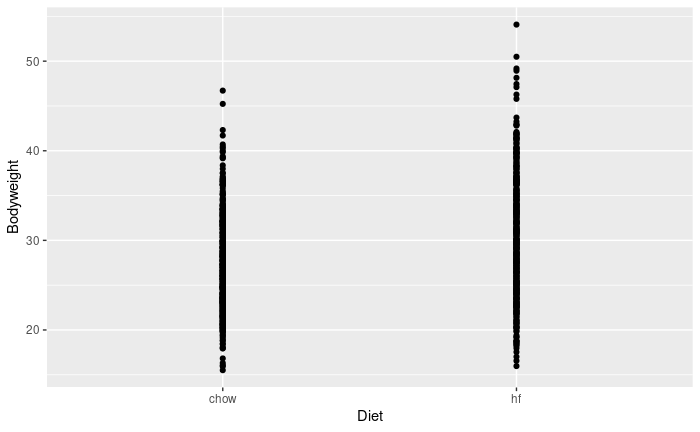

```r
weights_plot <- ggplot(data = mice_pheno, mapping = aes(x = Diet, y = Bodyweight))
weights_plot + geom_point()
```

The `+` in the `ggplot2` package is particularly useful because it allows you to modify existing `ggplot` objects.

*Notes**

- Anything you put in the `ggplot()` function can be seen by any geom layers that you add (i.e., these are universal plot settings). This includes the x- and y-axis mapping you set up in `aes()`;
- You can also specify mappings for a given geom independently of the mappings defined globally in the `ggplot()` function;
- The `+` sign used to add new layers must be placed at the end of the line containing the previous layer. If, instead, the `+` sign is added at the beginning of the line containing the new layer, `ggplot2` will not add the new layer and will return an error message.

```r
# This is the correct syntax for adding layers
weights_plot +
  geom_point()

# This will not add the new layer and will return an error message
weights_plot
  + geom_point()
```

## Plotting categorical data

Categories are encoded as factors or character. In our mice data, the diet and sex variable are categorical variables. In our plots, we want to compare the categories of these variables to each other, for example we want to compare the `chow` and `hf` diets to each other, with respect to the resulting mouse weight.

### Boxplot

A boxplot summarizes a few statistics on the data: The median, first and third quartile and outliers.

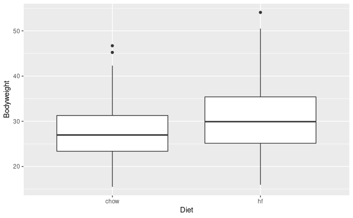

```r
weights_plot +
  geom_boxplot()
```

But even though this summary can be useful, some information on this original data points is lost. Therefore, it’s useful to overlay the data points on the boxes:

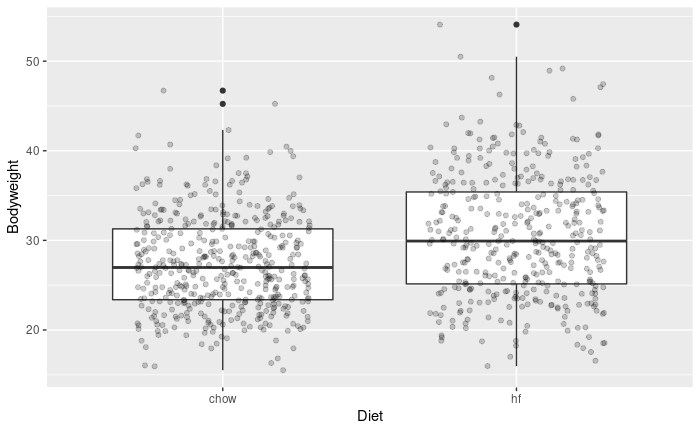

```r
weights_plot +
  geom_boxplot() +
  geom_jitter(width=.3, alpha=0.2)
```

Because there are quite a few data points, I use transparency and jitter to avoid overplotting.

### Violin plot

The violin plot is a nice tool to show the distributions in several categories in the same plot.

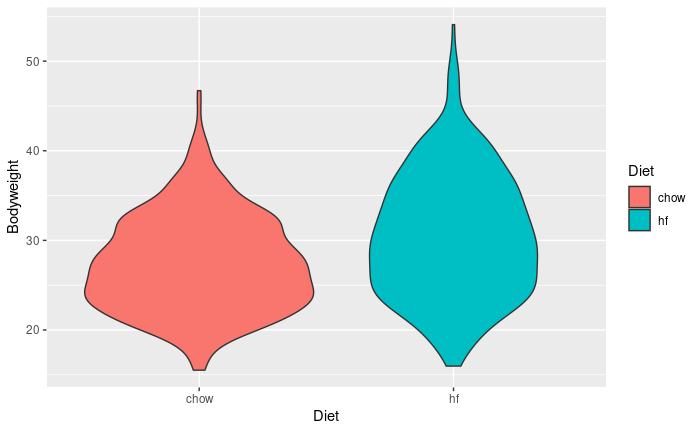

```r
weights_plot +
  geom_violin(aes(fill=Diet))
```

## More than two variables

If we look at the `mice_pheno` data set, we notice that we so far ignored one variable:

```r
str(mice_pheno)
```

```
'data.frame':   846 obs. of  3 variables:
 $ Sex       : chr  "F" "F" "F" "F" ...
 $ Diet      : chr  "hf" "hf" "hf" "hf" ...
 $ Bodyweight: num  31.9 32.5 22.8 19.9 32.2 ...
```

We have several options:

- Keep ignoring the sex variable;
- Subset the data frame for plotting;
- encode the Sex variable in the plot using tools like color or faceting.

### Combine filtering and plotting

We are comparing the two diets only for female mice:

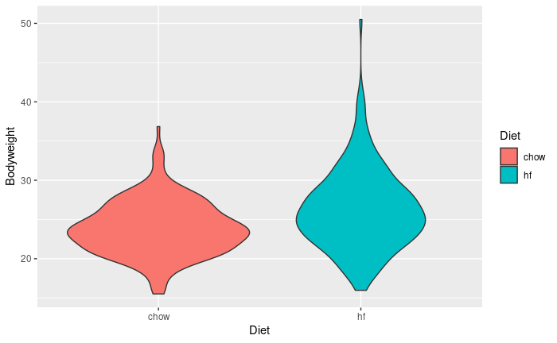

```r
mice_pheno %>%
  filter(Sex=="F") %>%
  ggplot(aes(x=Diet, y = Bodyweight)) +
  geom_violin(aes(fill=Diet))
```

### Faceting

Use the faceting option in `ggplot2` to create one sub-plot for each sex:

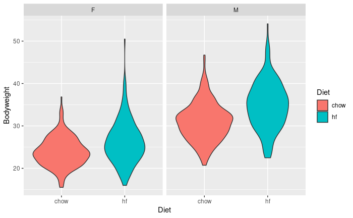

```r
weights_plot +
  geom_violin(aes(fill=Diet))+
  facet_wrap(vars(Sex))
```

### Encode a variable by color

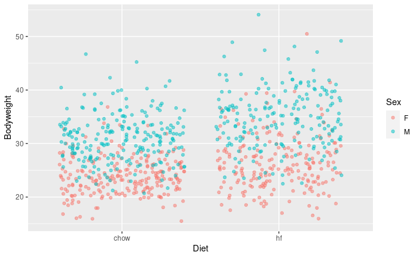

```r
weights_plot +
  geom_jitter(width=0.4,aes(colour=Sex), alpha=0.5)
```

To get a feeling for the data, it’s always recommended to look at individual points at least once. It’s also a matter of taste which graphics you find more enlightening. I personally find this plot useful, but also a bit messy, so I’d probably prefer faceting and violins.

In the testing block, we will see the rationale behind testing for weight differences between the two diets, or male and female mice.

## Continuous variables

Now, we are going to look at the `palmerpenguins` data. These are measurements of on three different penguin species on islands near the antarctic Palmer Station.

Penguins

```r
# install.packages("palmerpenguins")
library(palmerpenguins)
names(penguins)
```

```
[1] "species"           "island"            "bill_length_mm"    "bill_depth_mm"     "flipper_length_mm" "body_mass_g"       "sex"
[8] "year"
```

We can start exploring this data set by looking at the dimensions:

```r
dim(penguins)
```

```
[1] 344   8
```

Visualize individual relationships in a scatter plot, for example bill length and flipper length:

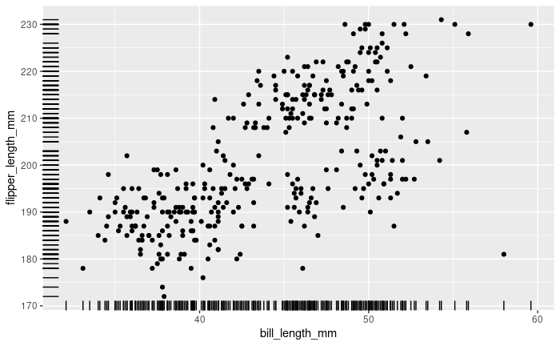

```r
ggplot(penguins, aes(x=bill_length_mm, y=flipper_length_mm)) +
  geom_point() +
  geom_rug()
```

We see a few patterns here, so maybe it is useful to point out a few other variables How about species or sex?

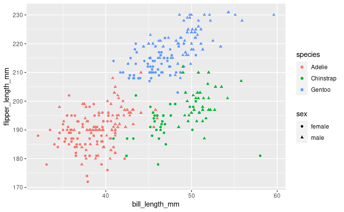

```r
penguins %>%
  filter(!is.na(sex)) %>%
  ggplot(aes(x=bill_length_mm, y=flipper_length_mm, colour=species, shape=sex)) +
  geom_point()
```

We can subset to female Gentoo and look at individual relationships:

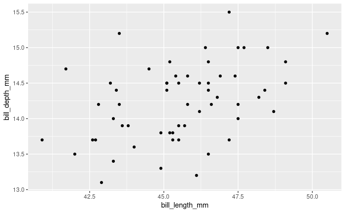

Now it’s easy to get lost in the details and individual plots and associations. Therefore, it’s always good to get an overview first. One convenient tool for that is the `GGally::ggpairs` function. Let’s suppose we are interested in the Gentoo, so we filter for them:

```r
# install.packages("GGally")
library(GGally)
```

```r
penguins %>%
  filter( species =="Gentoo" ) %>%
  select(bill_length_mm,  body_mass_g, flipper_length_mm) %>% describe()
```

```
.

 3  Variables      124  Observations
---------------------------------------------------------------------------------------------------------------------------------------------------------
bill_length_mm
       n  missing distinct     Info     Mean      Gmd      .05      .10      .25      .50      .75      .90      .95
     123        1       75        1     47.5     3.42    42.93    43.52    45.30    47.30    49.55    50.80    52.19

lowest : 40.9 41.7 42.0 42.6 42.7, highest: 53.4 54.3 55.1 55.9 59.6
---------------------------------------------------------------------------------------------------------------------------------------------------------
body_mass_g
       n  missing distinct     Info     Mean      Gmd      .05      .10      .25      .50      .75      .90      .95
     123        1       47    0.999     5076    579.6     4300     4400     4700     5000     5500     5700     5850

lowest : 3950 4100 4150 4200 4300, highest: 5850 5950 6000 6050 6300
---------------------------------------------------------------------------------------------------------------------------------------------------------
flipper_length_mm
       n  missing distinct     Info     Mean      Gmd      .05      .10      .25      .50      .75      .90      .95
     123        1       25    0.997    217.2    7.379      208      209      212      216      221      228      230

lowest : 203 207 208 209 210, highest: 226 228 229 230 231
---------------------------------------------------------------------------------------------------------------------------------------------------------
```

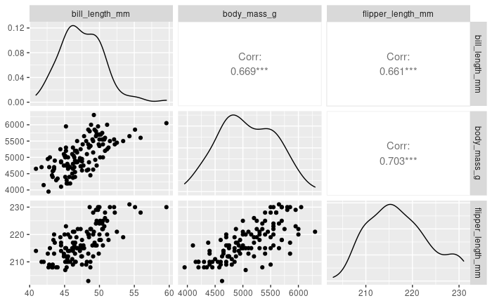

```r
penguins %>%
  filter( species =="Gentoo" ) %>%
  select(bill_length_mm,  body_mass_g, flipper_length_mm) %>%
  ggpairs()
```

This plot quickly tells us that bill length, flipper length and body mass are all positively correlated with each other. One way to interpret this is that they all somehow represent (or grow with) the size of the penguin.

We can use this interpretation to reduce the dimensionality of the data set for further analyses.

## Overplotting

This is a modified example from chapter 7 in the online book (R4ds)[https://r4ds.had.co.nz/exploratory-data-analysis.html] by Hadley Wickham and Garrett Grolemund.

We look at a data sets on diamonds. Data was collected on more than 50,000 diamonds’ price, carat, size, and some quality criteria. We will focus on the relation between carat and price, and we’ll also try to learn something about the distribution of the data.

```r
str(diamonds)
```

```
tibble [53,940 × 10] (S3: tbl_df/tbl/data.frame)
 $ carat  : num [1:53940] 0.23 0.21 0.23 0.29 0.31 0.24 0.24 0.26 0.22 0.23 ...
 $ cut    : Ord.factor w/ 5 levels "Fair"<"Good"<..: 5 4 2 4 2 3 3 3 1 3 ...
 $ color  : Ord.factor w/ 7 levels "D"<"E"<"F"<"G"<..: 2 2 2 6 7 7 6 5 2 5 ...
 $ clarity: Ord.factor w/ 8 levels "I1"<"SI2"<"SI1"<..: 2 3 5 4 2 6 7 3 4 5 ...
 $ depth  : num [1:53940] 61.5 59.8 56.9 62.4 63.3 62.8 62.3 61.9 65.1 59.4 ...
 $ table  : num [1:53940] 55 61 65 58 58 57 57 55 61 61 ...
 $ price  : int [1:53940] 326 326 327 334 335 336 336 337 337 338 ...
 $ x      : num [1:53940] 3.95 3.89 4.05 4.2 4.34 3.94 3.95 4.07 3.87 4 ...
 $ y      : num [1:53940] 3.98 3.84 4.07 4.23 4.35 3.96 3.98 4.11 3.78 4.05 ...
 $ z      : num [1:53940] 2.43 2.31 2.31 2.63 2.75 2.48 2.47 2.53 2.49 2.39 ...
```

We’ll cut off the carat at 2.5, because above that value, the data are sparse.

A good starting point for looking at the covariation of two variables is often a scatter plot:

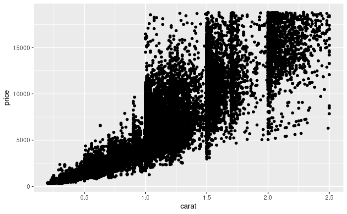

But we have a problem here: There are >50,000 data points, and they overlap heavily. From this plot, we can’t see where most of the data points lie. Anywhere in the black regions could be a huge, dense cloud of data points and anything else we see are just “outliers”. One thing to see more clearly is to make the points transparent:

[figure not shown]

You notice that the a lot of points are cramped towards the origin. You could try the log-scale:

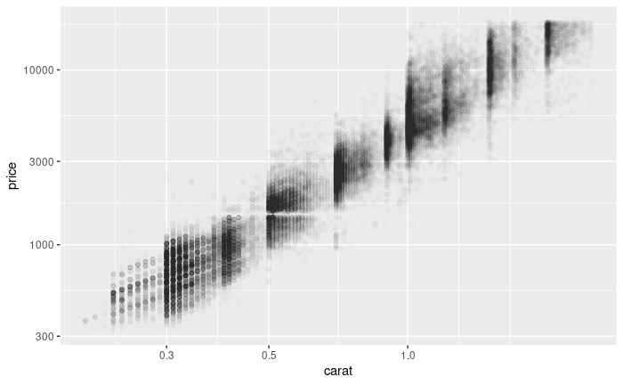

Or bin them - this is kind of a 2D histogram, where the counts are represented as colors:

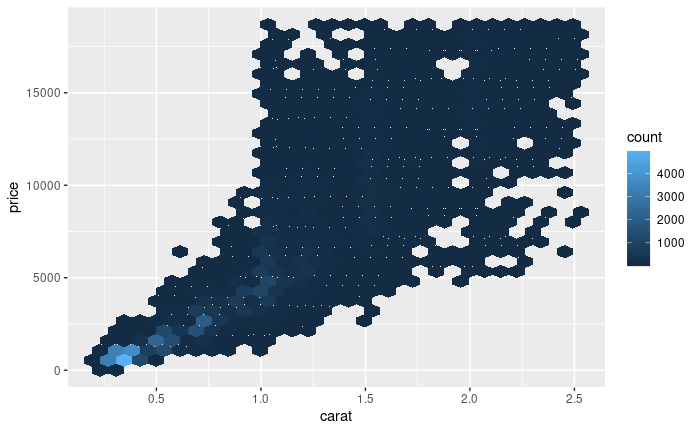

```r
# install.packages("hexbin")
library(hexbin)
ggplot(data = diamonds2) +
  geom_hex(mapping = aes(x = carat, y = price))
```

By looking at the data in these different ways, we have gotten the idea, that a lot of the diamonds have below 1 carat, and the relation between carat and price looks linear on the log-log-scale, which could be useful for modeling it.